# Problem Statement

- Over the years, the company has collected basic bank details and gathered a lot of credit-related information. The management wants to build an intelligent system to segregate the people into credit score brackets to reduce the manual efforts.

# Data Description

- Data has 2 Files Train Data and Test Data. Train data has 28 Columns and Test data has 27 Columns
- Columns:-
  - **ID**: Represents a unique identification of an entry
  - **Customer ID**: Represents a unique identification of a person
  - **Month**: Represents the month of the year
  - **Name**: Represents the name of a person
  - **Age**: Represents the age of the person
  - **SSN**: Represents the social security number of a person
  - **Occupation**: Represents the occupation of the person
  - **Annual_Income**: Represents the annual income of the person
  - **Monthly_Inhand_Salary**: Represents the monthly base salary of a person
  - **Num_Bank_Accounts**: Represents the number of bank accounts a person holds
  - **Num_Credit_Card**: Represents the number of other credit cards held by a person
  - **Interest_Rate**: Represents the interest rate on credit card
  - **Num_of_Loan**: Represents the number of loans taken from the bank
  - **Type_of_Loan**: Represents the types of loan taken by a person
  - **Delay_from_due_date**: Represents the average number of days delayed from the payment date
  - **Num_of_Delayed_Payment**: Represents the average number of payments delayed by a person
  - **Changed_Credit_Limit**: Represents the percentage change in credit card limit
  - **Num_Credit_Inquiries**: Represents the number of credit card inquiries
  - **Credit_Mix**: Represents the classification of the mix of credits
  - **Outstanding_Debt**: Represents the remaining debt to be paid (in USD)
  - **Credit_Utilization_Ratio**: Represents the utilization ratio of credit card
  - **Credit_History_Age**: Represents the age of credit history of the person
  - **Payment_of_Min_Amount**: Represents whether only the minimum amount was paid by the person
  - **Total_EMI_per_month**: Represents the Equated Monthly Installments payments (in USD)
  - **Amount_invested_monthly**: Represents the monthly amount invested by the customer (in USD)
  - **Payment_Behaviour**: Represents the payment behavior of the customer (in USD)
  - **Monthly_Balance**: Represents the monthly balance amount of the customer (in USD)
  - **Credit_Score**: Represents the bracket of credit score (Poor, Standard, Good)

# Importing Libraries

```python
import pandas as pd
import matplotlib.pyplot as plt
import numpy as np
import seaborn as sns
import warnings
warnings.filterwarnings('ignore')
```

```python
df = pd.read_csv("train.csv", sep = "," , encoding = 'utf-8')
test = pd.read_csv("test.csv", sep = "," , encoding = 'utf-8')
```

```python
df.head()
```

[output not shown]

```python
df.info()
```

```
<class 'pandas.core.frame.DataFrame'>
RangeIndex: 100000 entries, 0 to 99999
Data columns (total 28 columns):
 #   Column                    Non-Null Count   Dtype
---  ------                    --------------   -----
 0   ID                        100000 non-null  object
 1   Customer_ID               100000 non-null  object
 2   Month                     100000 non-null  object
 3   Name                      90015 non-null   object
 4   Age                       100000 non-null  object
 5   SSN                       100000 non-null  object
 6   Occupation                100000 non-null  object
 7   Annual_Income             100000 non-null  object
 8   Monthly_Inhand_Salary     84998 non-null   float64
 9   Num_Bank_Accounts         100000 non-null  int64
```

[output cut: 20 more lines]

# Data Cleaning & Preprocessing

```python
def filling_na(df, column, type_=None):
    """
    This fucntion for filling null values to work with the data properly
    Parameters:
    df: DataFrame to fill the na with
    column: column which will fill the value in it
    type_: type of data needed be filled

    """
    np.random.seed(7)
    if type_ == "num":
        filling_list = df[column].dropna()
        df[column] = df[column].fillna(pd.Series(np.random.choice(filling_list, size=len(df.index))))

    else:
        filling_list = df[column].dropna().unique()
        df[column] = df[column].fillna(pd.Series(np.random.choice(filling_list, size=len(df.index))))
    return df[column]
```

```python
df[df["Amount_invested_monthly"]=="__10000__"]
```

|  | ID | Customer_ID | Month | Name | Age | SSN | Occupation | Annual_Income | Monthly_Inhand_Salary | Num_Bank_Accounts | ... | Credit_Mix | Outstanding_Debt | Credit_Utilization_Ratio | Credit_History_Age | Payment_of_Min_Amount | Total_EMI_per_month | Amount_invested_monthly | Payment_Behaviour | Monthly_Balance | Credit_Score |
| --- | --- | --- | --- | --- | --- | --- | --- | --- | --- | --- | --- | --- | --- | --- | --- | --- | --- | --- | --- | --- | --- |
| 18 | 0x161c | CUS_0x2dbc | March | Langep | 34 | 486-85-3974 | _______ | 143162.64 | NaN | 1 | ... | Good | 1303.01 | 26.519815 | 17 Years and 11 Months | No | 246.992319 | __10000__ | High_spent_Small_value_payments | 715.741367403555 | Good |
| 23 | 0x1621 | CUS_0x2dbc | August | Langep | 34 | 486-85-3974 | Engineer | 143162.64 | 12187.220000 | 1 | ... | Good | 1303.01 | 38.374753 | 18 Years and 4 Months | No | 246.992319 | __10000__ | High_spent_Small_value_payments | 895.494583180492 | Standard |
| 28 | 0x162a | CUS_0xb891 | May | Jasond | 55 | 072-31-6145 | Entrepreneur | 30689.89 | 2612.490833 | 2 | ... | Good | 632.46 | 41.154317 | 17 Years and 7 Months | No | 16.415452 | __10000__ | Low_spent_Large_value_payments | 359.37491550776383 | Standard |
| 121 | 0x16b7 | CUS_0x33d2 | February | Chalmersa | 30 | 965-46-2491 | Scientist | 31993.78 | 2942.148333 | 6 | ... | Standard | 818.22 | 37.958569 | 16 Years and 11 Months | Yes | 45.141298 | __10000__ | Low_spent_Small_value_payments | 157.86980351234496 | Standard |
| 142 | 0x16d4 | CUS_0xfdb | July | Patrickg | 46 | 928-91-4452 | Teacher | 32284.62 | 2898.385000 | 6 | ... | Standard | 1283.37_ | 24.205533 | 6 Years and 11 Months | Yes | 103.037560 | __10000__ | Low_spent_Small_value_payments | 85.90209492602362 | Standard |
| ... | ... | ... | ... | ... | ... | ... | ... | ... | ... | ... | ... | ... | ... | ... | ... | ... | ... | ... | ... | ... | ... |
| 99879 | 0x25f39 | CUS_0x3855 | August | Xolai | 27 | #F%$D@*&8 | Scientist | 118677.54 | 9963.795000 | 4 | ... | Good | 995.47 | 39.747228 | 30 Years and 6 Months | No | 237.106366 | __10000__ | High_spent_Medium_value_payments | 801.752296 | Good |
| 99882 | 0x25f40 | CUS_0x47fa | March | Yantoultra Nguif | 31 | 291-51-7240 | Mechanic | 16884797.0 | 5440.945000 | 7 | ... | Standard | 330.6 | 38.524095 | 23 Years and 0 Months | Yes | 0.000000 | __10000__ | High_spent_Small_value_payments | 536.34292 | Standard |
| 99919 | 0x25f75 | CUS_0x1619 | August | Phil Wahbao | 54 | 683-59-7399 | Media_Manager | 20059.98 | 1523.665000 | 8 | ... | Good | 909.01 | 32.473773 | 16 Years and 10 Months | No | 45.076827 | __10000__ | Low_spent_Small_value_payments | 267.184985 | Poor |
| 99951 | 0x25fa5 | CUS_0x51b3 | August | Ryana | 33 | 837-85-9800 | Media_Manager | 59146.36 | 4908.863333 | 3 | ... | Good | 418.03 | 27.682186 | 20 Years and 8 Months | No | 26.778419 | __10000__ | Low_spent_Large_value_payments | 389.488483 | Standard |
| 99973 | 0x25fc7 | CUS_0xf16 | June | NaN | 45 | 868-70-2218 | Media_Manager | 16680.35 | 1528.029167 | 1 | ... | Good | 897.16 | 24.972853 | 21 Years and 6 Months | No | 41.113561 | __10000__ | Low_spent_Small_value_payments | 233.301539 | Good |

4305 rows × 28 columns

```python
df.describe().T
```

|  | count | mean | std | min | 25% | 50% | 75% | max |
| --- | --- | --- | --- | --- | --- | --- | --- | --- |
| Monthly_Inhand_Salary | 84998.0 | 4194.170850 | 3183.686167 | 303.645417 | 1625.568229 | 3093.745000 | 5957.448333 | 15204.633333 |
| Num_Bank_Accounts | 100000.0 | 17.091280 | 117.404834 | -1.000000 | 3.000000 | 6.000000 | 7.000000 | 1798.000000 |
| Num_Credit_Card | 100000.0 | 22.474430 | 129.057410 | 0.000000 | 4.000000 | 5.000000 | 7.000000 | 1499.000000 |
| Interest_Rate | 100000.0 | 72.466040 | 466.422621 | 1.000000 | 8.000000 | 13.000000 | 20.000000 | 5797.000000 |
| Delay_from_due_date | 100000.0 | 21.068780 | 14.860104 | -5.000000 | 10.000000 | 18.000000 | 28.000000 | 67.000000 |
| Num_Credit_Inquiries | 98035.0 | 27.754251 | 193.177339 | 0.000000 | 3.000000 | 6.000000 | 9.000000 | 2597.000000 |
| Credit_Utilization_Ratio | 100000.0 | 32.285173 | 5.116875 | 20.000000 | 28.052567 | 32.305784 | 36.496663 | 50.000000 |
| Total_EMI_per_month | 100000.0 | 1403.118217 | 8306.041270 | 0.000000 | 30.306660 | 69.249473 | 161.224249 | 82331.000000 |

```python
df.describe(include='O').T
```

|  | count | unique | top | freq |
| --- | --- | --- | --- | --- |
| ID | 100000 | 100000 | 0x1602 | 1 |
| Customer_ID | 100000 | 12500 | CUS_0xd40 | 8 |
| Month | 100000 | 8 | January | 12500 |
| Name | 90015 | 10139 | Langep | 44 |
| Age | 100000 | 1788 | 38 | 2833 |
| SSN | 100000 | 12501 | #F%$D@*&8 | 5572 |
| Occupation | 100000 | 16 | _______ | 7062 |
| Annual_Income | 100000 | 18940 | 36585.12 | 16 |
| Num_of_Loan | 100000 | 434 | 3 | 14386 |
| Type_of_Loan | 88592 | 6260 | Not Specified | 1408 |
| Num_of_Delayed_Payment | 92998 | 749 | 19 | 5327 |
| Changed_Credit_Limit | 100000 | 4384 | _ | 2091 |
| Credit_Mix | 100000 | 4 | Standard | 36479 |
| Outstanding_Debt | 100000 | 13178 | 1360.45 | 24 |
| Credit_History_Age | 90970 | 404 | 15 Years and 11 Months | 446 |
| Payment_of_Min_Amount | 100000 | 3 | Yes | 52326 |
| Amount_invested_monthly | 95521 | 91049 | __10000__ | 4305 |
| Payment_Behaviour | 100000 | 7 | Low_spent_Small_value_payments | 25513 |
| Monthly_Balance | 98800 | 98792 | __-333333333333333333333333333__ | 9 |
| Credit_Score | 100000 | 3 | Standard | 53174 |

```python
df["Amount_invested_monthly"] = df["Amount_invested_monthly"].replace("__10000__", 10000.00)
df["Amount_invested_monthly"] = df["Amount_invested_monthly"].astype("float64")
df["Amount_invested_monthly"].dtype
```

```
dtype('float64')
```

```python
df["Monthly_Balance"] = df["Monthly_Balance"].replace("__-333333333333333333333333333__", -333333333333333333333333333.00)
df["Monthly_Balance"] = df["Monthly_Balance"].astype("float64")
df["Monthly_Balance"].dtype
```

```
dtype('float64')
```

```python
df["Num_of_Delayed_Payment"] = df["Num_of_Delayed_Payment"].str.replace(r'_$',"", regex=True)
df["Num_of_Delayed_Payment"] = df["Num_of_Delayed_Payment"].astype("float64")
df["Num_of_Delayed_Payment"].dtype
```

```
dtype('float64')
```

```python
df["Annual_Income"] = df["Annual_Income"].str.replace(r'_$',"", regex=True)
df["Annual_Income"] = df["Annual_Income"].astype("float64")
df["Annual_Income"].dtype
```

```
dtype('float64')
```

```python
df["Age"] = df["Age"].str.replace(r'_$',"", regex=True)
df["Age"] = df["Age"].astype("int64")
df["Age"].dtype
```

```
dtype('int64')
```

```python
df["Outstanding_Debt"] = df["Outstanding_Debt"].str.replace(r'_$',"", regex=True)
df["Outstanding_Debt"] = df["Outstanding_Debt"].astype("float64")
df["Outstanding_Debt"].dtype
```

```
dtype('float64')
```

```python
df["Occupation"] = df["Occupation"].replace("_______",np.nan)
```

```python
df["Credit_History_Age_#Year"] = df["Credit_History_Age"].str.split(" ", expand=True)[0]
df["Credit_History_Age_#Month"] = df["Credit_History_Age"].str.split(" ", expand=True)[3]
```

```python
df["Payment_Behaviour"] = df["Payment_Behaviour"].replace("!@9#%8","Medium_spent_Medium_value_payments")
```

```python
df.Age.replace(-500, np.median(df.Age), inplace=True)
for i in df.Age.values:
    if i > 118:
        df.Age.replace(i, np.median(df.Age), inplace=True)
```

```python
df["Num_of_Loan"] = df["Num_of_Loan"].str.replace(r'_$',"", regex=True)
df["Num_of_Loan"] = df["Num_of_Loan"].astype("int64")
df["Num_of_Loan"].dtype
```

```
dtype('int64')
```

```python
df["Credit_Mix"] = df["Credit_Mix"].replace("_", "Don't Have")
```

```python
df["Changed_Credit_Limit"] = df["Changed_Credit_Limit"].replace("_", 0)
df["Changed_Credit_Limit"] = df["Changed_Credit_Limit"].astype("float64")
```

```python
df.Num_of_Loan.replace(-100, np.median(df.Num_of_Loan), inplace=True)
for i in df.Num_of_Loan.values:
    if i > 10:
        df.Num_of_Loan.replace(i, np.median(df.Num_of_Loan), inplace=True)
```

```python
df["Interest_Rate"] = df["Interest_Rate"].astype("float64")
df["Interest_Rate"] = df["Interest_Rate"]/100
```

```python
for i in df.Interest_Rate:
    if i > 20:
        df.Interest_Rate.replace(i, np.median(df.Interest_Rate), inplace=True)
```

```python
for i in df.Num_Bank_Accounts:
    if i > 100:
        df.Num_Bank_Accounts.replace(i, np.median(df.Num_Bank_Accounts), inplace=True)
```

```python
df["Monthly_Inhand_Salary"] = filling_na(df, "Monthly_Inhand_Salary", "num")
df["Num_Credit_Inquiries"] = filling_na(df, "Num_Credit_Inquiries", "num")
df["Amount_invested_monthly"] = filling_na(df, "Amount_invested_monthly", "num")
df["Num_of_Delayed_Payment"] = filling_na(df, "Num_of_Delayed_Payment", "num")
df["Monthly_Balance"] = filling_na(df, "Monthly_Balance", "num")
df["Credit_History_Age_#Year"] = filling_na(df, "Credit_History_Age_#Year", "num")
df["Credit_History_Age_#Month"] = filling_na(df, "Credit_History_Age_#Month", "num")
df["Type_of_Loan"] = filling_na(df, "Type_of_Loan")
df["Credit_History_Age"] = filling_na(df, "Credit_History_Age")
df["Occupation"] = filling_na(df, "Occupation")
```

```python
df["Credit_History_Age_#Year"] = df["Credit_History_Age_#Year"].astype("int64")
df["Credit_History_Age_#Month"] = df["Credit_History_Age_#Month"].astype("int64")
```

```python
df.drop_duplicates(subset="ID", inplace=True)
```

```python
df.drop(["Name", "Credit_History_Age", "ID", "Customer_ID","SSN"], axis=1, inplace=True)
```

```python
df.Type_of_Loan = df.Type_of_Loan.str.replace("and", "")
df.Type_of_Loan = df.Type_of_Loan.str.replace(" ", "")
```

```python
cat_values=[]
loan_cat = df.Type_of_Loan.unique()
for i in loan_cat:
    for j in i.split(","):
        cat_values.append(j)
```

```python
loan_types = set([x.strip(' ') for x in set(cat_values)])
loan_types = list(loan_types)
loan_types
```

```
['PaydayLoan',
 'PersonalLoan',
 'HomeEquityLoan',
 'AutoLoan',
 'StudentLoan',
 'NotSpecified',
 'DebtConsolidationLoan',
 'Credit-BuilderLoan',
 'MortgageLoan']
```

```python
df.head()
```

|  | Month | Age | Occupation | Annual_Income | Monthly_Inhand_Salary | Num_Bank_Accounts | Num_Credit_Card | Interest_Rate | Num_of_Loan | Type_of_Loan | ... | Outstanding_Debt | Credit_Utilization_Ratio | Payment_of_Min_Amount | Total_EMI_per_month | Amount_invested_monthly | Payment_Behaviour | Monthly_Balance | Credit_Score | Credit_History_Age_#Year | Credit_History_Age_#Month |
| --- | --- | --- | --- | --- | --- | --- | --- | --- | --- | --- | --- | --- | --- | --- | --- | --- | --- | --- | --- | --- | --- |
| 0 | January | 23 | Scientist | 19114.12 | 1824.843333 | 3 | 4 | 0.03 | 4 | AutoLoan,Credit-BuilderLoan,PersonalLoan,HomeE... | ... | 809.98 | 26.822620 | No | 49.574949 | 80.415295 | High_spent_Small_value_payments | 312.494089 | Good | 22 | 1 |
| 1 | February | 23 | Scientist | 19114.12 | 1082.203750 | 3 | 4 | 0.03 | 4 | AutoLoan,Credit-BuilderLoan,PersonalLoan,HomeE... | ... | 809.98 | 31.944960 | No | 49.574949 | 118.280222 | Low_spent_Large_value_payments | 284.629162 | Good | 26 | 5 |
| 2 | March | 33 | Scientist | 19114.12 | 2686.018333 | 3 | 4 | 0.03 | 4 | AutoLoan,Credit-BuilderLoan,PersonalLoan,HomeE... | ... | 809.98 | 28.609352 | No | 49.574949 | 81.699521 | Low_spent_Medium_value_payments | 331.209863 | Good | 22 | 3 |
| 3 | April | 23 | Scientist | 19114.12 | 2201.945833 | 3 | 4 | 0.03 | 4 | AutoLoan,Credit-BuilderLoan,PersonalLoan,HomeE... | ... | 809.98 | 31.377862 | No | 49.574949 | 199.458074 | Low_spent_Small_value_payments | 223.451310 | Good | 22 | 4 |
| 4 | May | 23 | Scientist | 19114.12 | 1824.843333 | 3 | 4 | 0.03 | 4 | AutoLoan,Credit-BuilderLoan,PersonalLoan,HomeE... | ... | 809.98 | 24.797347 | No | 49.574949 | 41.420153 | High_spent_Medium_value_payments | 341.489231 | Good | 22 | 5 |

5 rows × 25 columns

```python
df.info()
```

```
<class 'pandas.core.frame.DataFrame'>
Int64Index: 100000 entries, 0 to 99999
Data columns (total 25 columns):
 #   Column                     Non-Null Count   Dtype
---  ------                     --------------   -----
 0   Month                      100000 non-null  object
 1   Age                        100000 non-null  int64
 2   Occupation                 100000 non-null  object
 3   Annual_Income              100000 non-null  float64
 4   Monthly_Inhand_Salary      100000 non-null  float64
 5   Num_Bank_Accounts          100000 non-null  int64
 6   Num_Credit_Card            100000 non-null  int64
 7   Interest_Rate              100000 non-null  float64
 8   Num_of_Loan                100000 non-null  int64
 9   Type_of_Loan               100000 non-null  object
```

[output cut: 17 more lines]

```python
df.describe().T
```

|  | count | mean | std | min | 25% | 50% | 75% | max |
| --- | --- | --- | --- | --- | --- | --- | --- | --- |
| Age | 100000.0 | 3.331899e+01 | 1.064554e+01 | 1.400000e+01 | 25.000000 | 33.000000 | 41.000000 | 1.180000e+02 |
| Annual_Income | 100000.0 | 1.764157e+05 | 1.429618e+06 | 7.005930e+03 | 19457.500000 | 37578.610000 | 72790.920000 | 2.419806e+07 |
| Monthly_Inhand_Salary | 100000.0 | 4.193254e+03 | 3.184554e+03 | 3.036454e+02 | 1625.485208 | 3089.424167 | 5964.883333 | 1.520463e+04 |
| Num_Bank_Accounts | 100000.0 | 5.410010e+00 | 2.951401e+00 | -1.000000e+00 | 3.000000 | 6.000000 | 7.000000 | 1.000000e+02 |
| Num_Credit_Card | 100000.0 | 2.247443e+01 | 1.290574e+02 | 0.000000e+00 | 4.000000 | 5.000000 | 7.000000 | 1.499000e+03 |
| Interest_Rate | 100000.0 | 2.144277e-01 | 9.483375e-01 | 1.000000e-02 | 0.080000 | 0.130000 | 0.200000 | 1.999000e+01 |
| Num_of_Loan | 100000.0 | 3.510550e+00 | 2.395985e+00 | 0.000000e+00 | 2.000000 | 3.000000 | 5.000000 | 9.000000e+00 |
| Delay_from_due_date | 100000.0 | 2.106878e+01 | 1.486010e+01 | -5.000000e+00 | 10.000000 | 18.000000 | 28.000000 | 6.700000e+01 |
| Num_of_Delayed_Payment | 100000.0 | 3.066927e+01 | 2.240522e+02 | -3.000000e+00 | 9.000000 | 14.000000 | 18.000000 | 4.397000e+03 |
| Changed_Credit_Limit | 100000.0 | 1.017179e+01 | 6.880628e+00 | -6.490000e+00 | 4.970000 | 9.250000 | 14.660000 | 3.697000e+01 |
| Num_Credit_Inquiries | 100000.0 | 2.779739e+01 | 1.934427e+02 | 0.000000e+00 | 3.000000 | 6.000000 | 9.000000 | 2.597000e+03 |
| Outstanding_Debt | 100000.0 | 1.426220e+03 | 1.155129e+03 | 2.300000e-01 | 566.072500 | 1166.155000 | 1945.962500 | 4.998070e+03 |
| Credit_Utilization_Ratio | 100000.0 | 3.228517e+01 | 5.116875e+00 | 2.000000e+01 | 28.052567 | 32.305784 | 36.496663 | 5.000000e+01 |
| Total_EMI_per_month | 100000.0 | 1.403118e+03 | 8.306041e+03 | 0.000000e+00 | 30.306660 | 69.249473 | 161.224249 | 8.233100e+04 |
| Amount_invested_monthly | 100000.0 | 6.386322e+02 | 2.046581e+03 | 0.000000e+00 | 74.569477 | 135.771365 | 265.460971 | 1.000000e+04 |
| Monthly_Balance | 100000.0 | -3.333333e+22 | 3.333183e+24 | -3.333333e+26 | 270.057822 | 336.649353 | 470.176839 | 1.602041e+03 |
| Credit_History_Age_#Year | 100000.0 | 1.797151e+01 | 8.314654e+00 | 0.000000e+00 | 12.000000 | 18.000000 | 25.000000 | 3.300000e+01 |
| Credit_History_Age_#Month | 100000.0 | 5.596880e+00 | 3.450257e+00 | 0.000000e+00 | 3.000000 | 5.000000 | 9.000000 | 1.100000e+01 |

```python
df.describe(include='O').T
```

|  | count | unique | top | freq |
| --- | --- | --- | --- | --- |
| Month | 100000 | 8 | January | 12500 |
| Occupation | 100000 | 15 | Lawyer | 7093 |
| Type_of_Loan | 100000 | 6260 | NotSpecified | 1409 |
| Credit_Mix | 100000 | 4 | Standard | 36479 |
| Payment_of_Min_Amount | 100000 | 3 | Yes | 52326 |
| Payment_Behaviour | 100000 | 7 | Low_spent_Small_value_payments | 25513 |
| Credit_Score | 100000 | 3 | Standard | 53174 |

# Exploratory Data Analysis

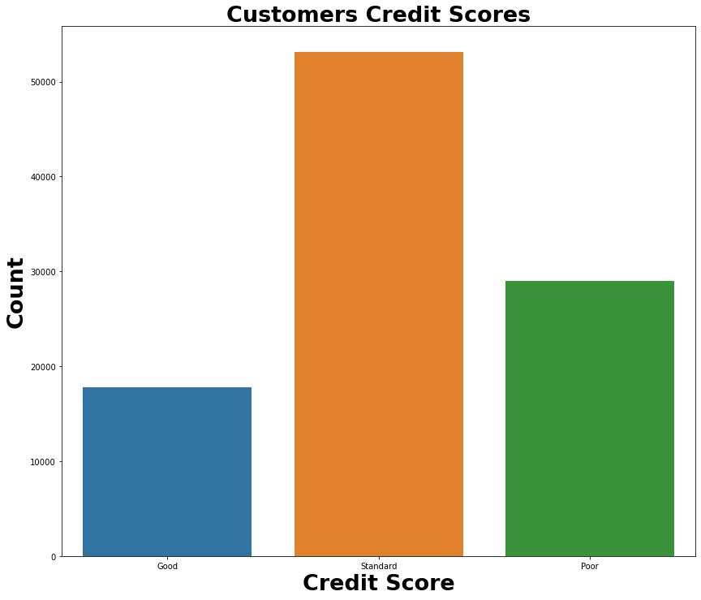

```python
plt.figure(figsize=(14,12))
sns.countplot(data = df, x="Credit_Score")
plt.title("Customers Credit Scores", size=27,fontweight="bold")
plt.xlabel("Credit Score", size=27,fontweight="bold")
plt.ylabel("Count", size=27,fontweight="bold")
plt.show()
```

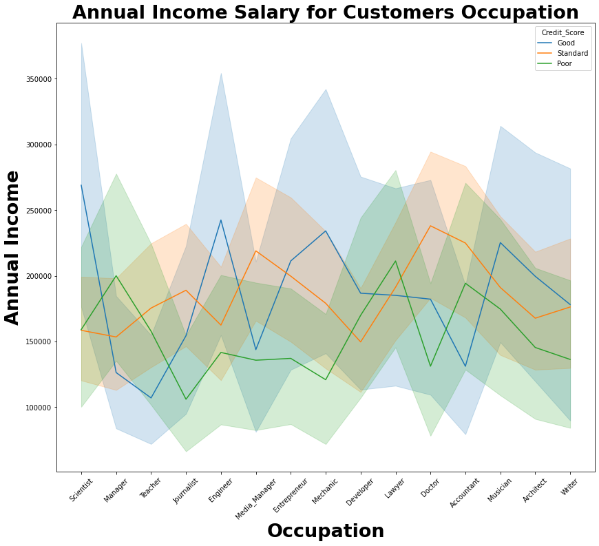

```python
plt.figure(figsize=(14,12))
sns.lineplot(data=df, x="Occupation", y="Annual_Income", hue="Credit_Score")
plt.xticks(rotation=45)
plt.title("Annual Income Salary for Customers Occupation", size=27,fontweight="bold")
plt.xlabel("Occupation", size=27,fontweight="bold")
plt.ylabel("Annual Income", size=27,fontweight="bold")
plt.show()
```

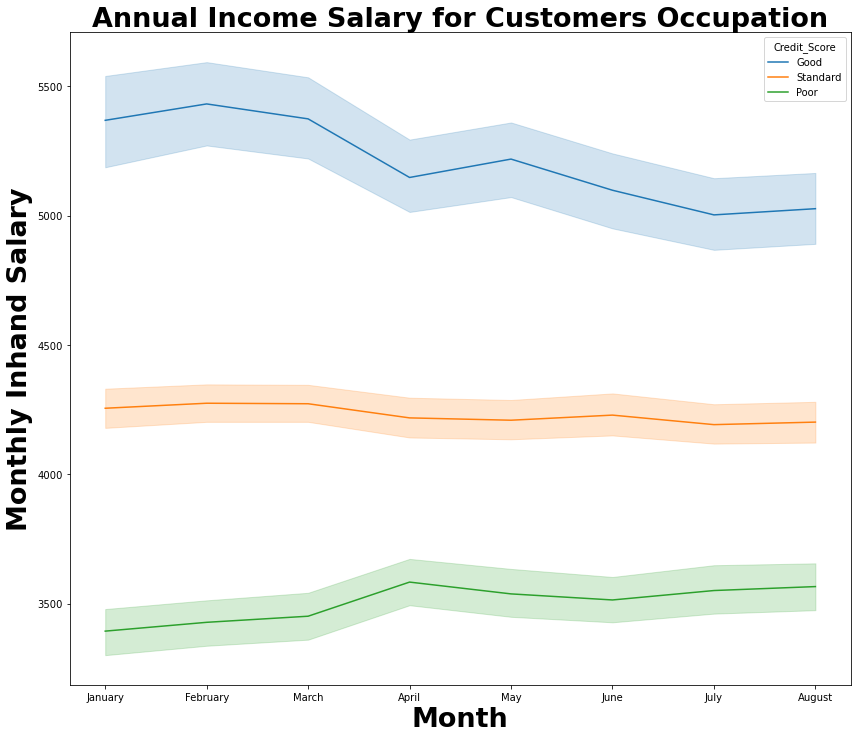

```python
plt.figure(figsize=(14,12))
sns.lineplot(data=df, x="Month", y="Monthly_Inhand_Salary", hue="Credit_Score")
plt.title("Annual Income Salary for Customers Occupation", size=27,fontweight="bold")
plt.xlabel("Month", size=27,fontweight="bold")
plt.ylabel("Monthly Inhand Salary", size=27,fontweight="bold")
plt.show()
```

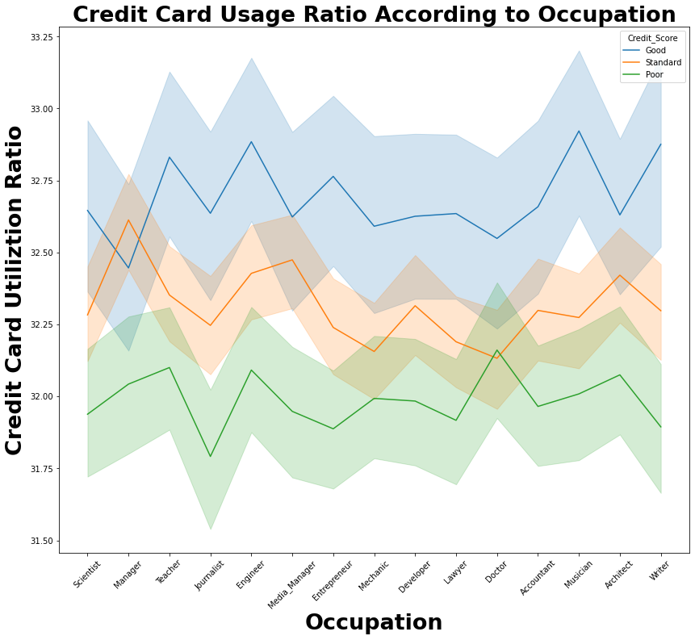

```python
plt.figure(figsize=(14,12))
sns.lineplot(data=df, x="Occupation", y="Credit_Utilization_Ratio", hue="Credit_Score")
plt.xticks(rotation=45)
plt.title("Credit Card Usage Ratio According to Occupation", size=27,fontweight="bold")
plt.xlabel("Occupation", size=27,fontweight="bold")
plt.ylabel("Credit Card Utiliztion Ratio", size=27,fontweight="bold")
plt.show()
```

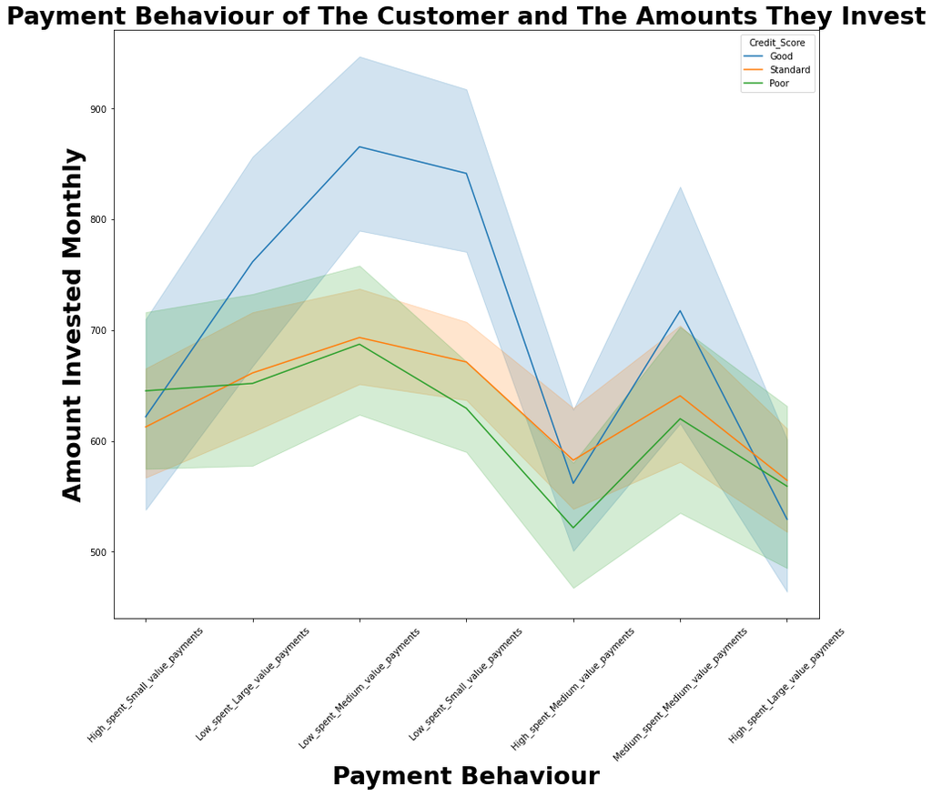

```python
plt.figure(figsize=(14,12))
sns.lineplot(data=df, x="Payment_Behaviour", y="Amount_invested_monthly", hue="Credit_Score")
plt.xticks(rotation=45)
plt.title("Payment Behaviour of The Customer and The Amounts They Invest", size=27,fontweight="bold")
plt.xlabel("Payment Behaviour", size=27,fontweight="bold")
plt.ylabel("Amount Invested Monthly", size=27,fontweight="bold")
plt.show()
```

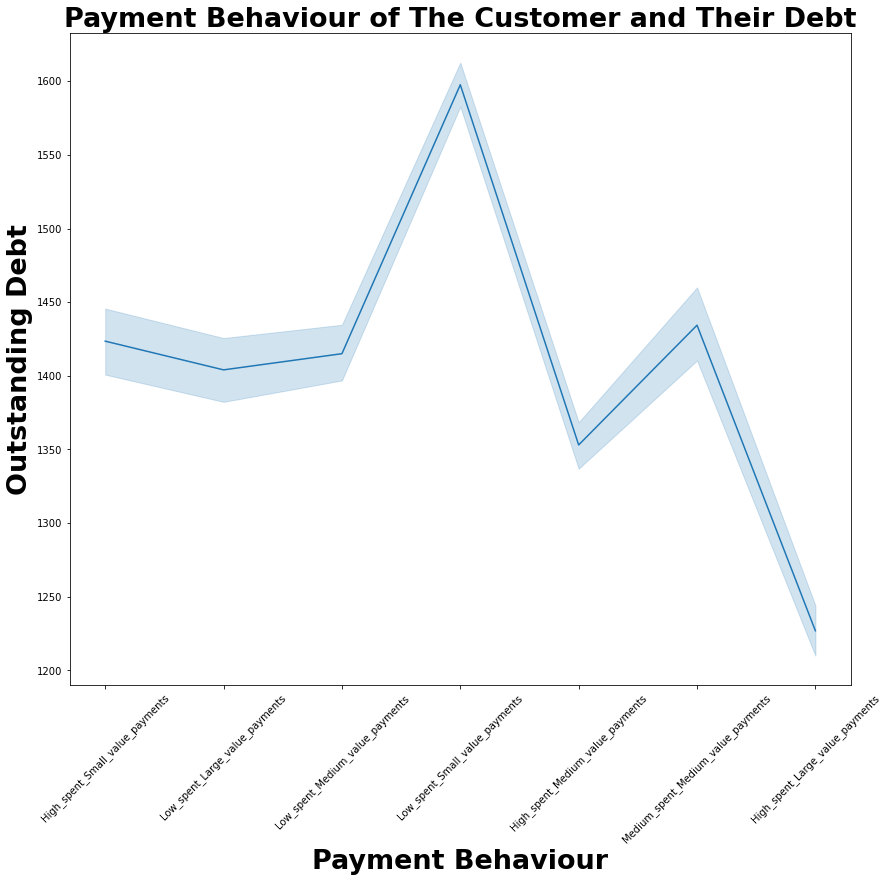

```python
plt.figure(figsize=(14,12))
sns.lineplot(data=df, x="Payment_Behaviour", y="Outstanding_Debt")
plt.xticks(rotation=45)
plt.title("Payment Behaviour of The Customer and Their Debt", size=27,fontweight="bold")
plt.xlabel("Payment Behaviour", size=27,fontweight="bold")
plt.ylabel("Outstanding Debt", size=27,fontweight="bold")
plt.show()
```

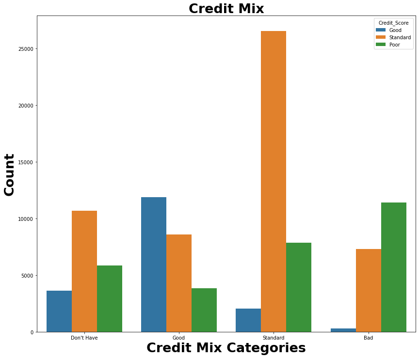

```python
plt.figure(figsize=(14,12))
sns.countplot(data=df, x="Credit_Mix", hue="Credit_Score")
#plt.xticks(rotation=45)
plt.title("Credit Mix", size=27,fontweight="bold")
plt.xlabel("Credit Mix Categories", size=27,fontweight="bold")
plt.ylabel("Count", size=27,fontweight="bold")
plt.show()
```

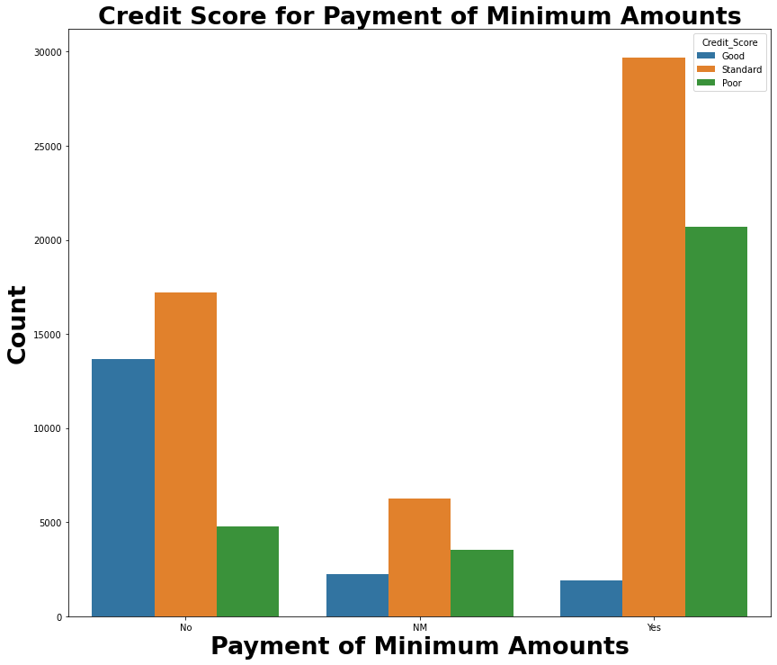

```python
plt.figure(figsize=(14,12))
sns.countplot(data = df, x = 'Payment_of_Min_Amount',hue="Credit_Score")
plt.title("Credit Score for Payment of Minimum Amounts", size=27,fontweight="bold")
plt.xlabel("Payment of Minimum Amounts", size=27,fontweight="bold")
plt.ylabel("Count", size=27,fontweight="bold")
plt.show()
```

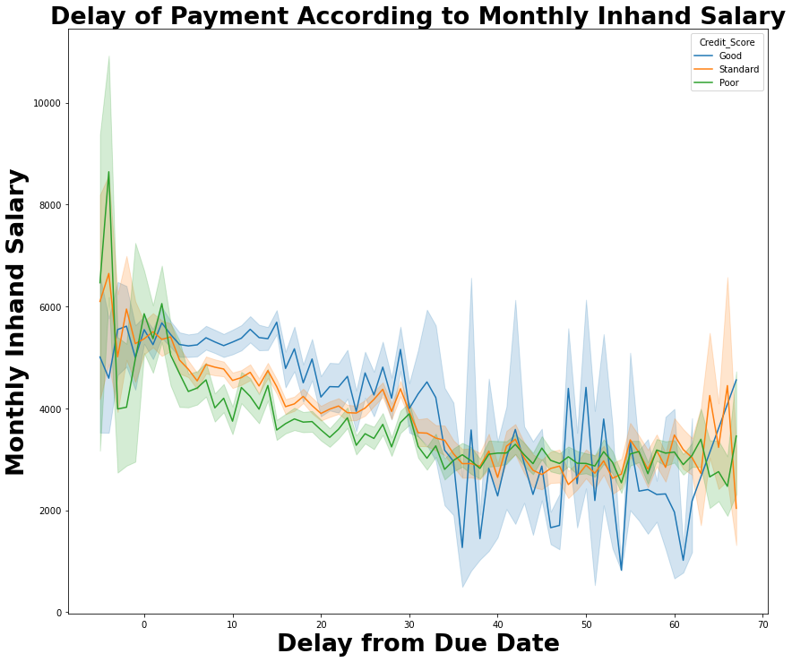

```python
plt.figure(figsize=(14,12))
sns.lineplot(data = df, x = 'Delay_from_due_date', y = 'Monthly_Inhand_Salary', hue="Credit_Score")
plt.title("Delay of Payment According to Monthly Inhand Salary", size=27,fontweight="bold")
plt.xlabel("Delay from Due Date", size=27,fontweight="bold")
plt.ylabel("Monthly Inhand Salary", size=27,fontweight="bold")
plt.show()
```

```python
df["Age_Group"] = pd.cut(df.Age, bins=[14,25,30,45,55,95,120])
age_groups = df.groupby(["Age_Group", "Credit_Score"])["Outstanding_Debt"].sum().to_frame().reset_index()
age_groups
```

|  | Age_Group | Credit_Score | Outstanding_Debt |
| --- | --- | --- | --- |
| 0 | (14, 25] | Good | 3137180.79 |
| 1 | (14, 25] | Poor | 19005227.84 |
| 2 | (14, 25] | Standard | 19952090.01 |
| 3 | (25, 30] | Good | 1825730.64 |
| 4 | (25, 30] | Poor | 9617599.66 |
| 5 | (25, 30] | Standard | 9651424.60 |
| 6 | (30, 45] | Good | 6071054.67 |
| 7 | (30, 45] | Poor | 28685654.13 |
| 8 | (30, 45] | Standard | 31548539.35 |
| 9 | (45, 55] | Good | 3116857.45 |
| 10 | (45, 55] | Poor | 1596323.10 |
| 11 | (45, 55] | Standard | 5631458.47 |
| 12 | (55, 95] | Good | 96907.67 |
| 13 | (55, 95] | Poor | 52396.44 |
| 14 | (55, 95] | Standard | 178580.28 |
| 15 | (95, 120] | Good | 1137.57 |
| 16 | (95, 120] | Poor | 4100.65 |
| 17 | (95, 120] | Standard | 5851.26 |

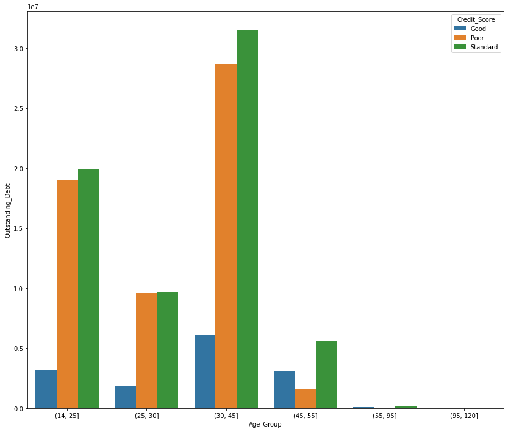

```python
plt.figure(figsize=(14,12))
sns.barplot(data=age_groups, x="Age_Group", y="Outstanding_Debt", hue="Credit_Score")
```

**Comment:**

- Customers Between age of 30 and 45 the most category who have a lot of outstanding debts which mean that people in their youth age have a high purchase power.

```python
df.head().T
```

|  | 0 | 1 | 2 | 3 | 4 |
| --- | --- | --- | --- | --- | --- |
| Month | January | February | March | April | May |
| Age | 23 | 23 | 33 | 23 | 23 |
| Occupation | Scientist | Scientist | Scientist | Scientist | Scientist |
| Annual_Income | 19114.12 | 19114.12 | 19114.12 | 19114.12 | 19114.12 |
| Monthly_Inhand_Salary | 1824.843333 | 1082.20375 | 2686.018333 | 2201.945833 | 1824.843333 |
| Num_Bank_Accounts | 3 | 3 | 3 | 3 | 3 |
| Num_Credit_Card | 4 | 4 | 4 | 4 | 4 |
| Interest_Rate | 0.03 | 0.03 | 0.03 | 0.03 | 0.03 |
| Num_of_Loan | 4 | 4 | 4 | 4 | 4 |
| Type_of_Loan | AutoLoan,Credit-BuilderLoan,PersonalLoan,HomeE... | AutoLoan,Credit-BuilderLoan,PersonalLoan,HomeE... | AutoLoan,Credit-BuilderLoan,PersonalLoan,HomeE... | AutoLoan,Credit-BuilderLoan,PersonalLoan,HomeE... | AutoLoan,Credit-BuilderLoan,PersonalLoan,HomeE... |
| Delay_from_due_date | 3 | -1 | 3 | 5 | 6 |
| Num_of_Delayed_Payment | 7.0 | 17.0 | 7.0 | 4.0 | 16.0 |
| Changed_Credit_Limit | 11.27 | 11.27 | 0.0 | 6.27 | 11.27 |
| Num_Credit_Inquiries | 4.0 | 4.0 | 4.0 | 4.0 | 4.0 |
| Credit_Mix | Don't Have | Good | Good | Good | Good |
| Outstanding_Debt | 809.98 | 809.98 | 809.98 | 809.98 | 809.98 |
| Credit_Utilization_Ratio | 26.82262 | 31.94496 | 28.609352 | 31.377862 | 24.797347 |
| Payment_of_Min_Amount | No | No | No | No | No |
| Total_EMI_per_month | 49.574949 | 49.574949 | 49.574949 | 49.574949 | 49.574949 |
| Amount_invested_monthly | 80.415295 | 118.280222 | 81.699521 | 199.458074 | 41.420153 |
| Payment_Behaviour | High_spent_Small_value_payments | Low_spent_Large_value_payments | Low_spent_Medium_value_payments | Low_spent_Small_value_payments | High_spent_Medium_value_payments |
| Monthly_Balance | 312.494089 | 284.629162 | 331.209863 | 223.45131 | 341.489231 |
| Credit_Score | Good | Good | Good | Good | Good |
| Credit_History_Age_#Year | 22 | 26 | 22 | 22 | 22 |
| Credit_History_Age_#Month | 1 | 5 | 3 | 4 | 5 |
| Age_Group | (14, 25] | (14, 25] | (30, 45] | (14, 25] | (14, 25] |

```python
test_df = pd.DataFrame(df.Type_of_Loan)
test_df
```

|  | Type_of_Loan |
| --- | --- |
| 0 | AutoLoan,Credit-BuilderLoan,PersonalLoan,HomeE... |
| 1 | AutoLoan,Credit-BuilderLoan,PersonalLoan,HomeE... |
| 2 | AutoLoan,Credit-BuilderLoan,PersonalLoan,HomeE... |
| 3 | AutoLoan,Credit-BuilderLoan,PersonalLoan,HomeE... |
| 4 | AutoLoan,Credit-BuilderLoan,PersonalLoan,HomeE... |
| ... | ... |
| 99995 | AutoLoan,StudentLoan |
| 99996 | AutoLoan,StudentLoan |
| 99997 | AutoLoan,StudentLoan |
| 99998 | AutoLoan,StudentLoan |
| 99999 | AutoLoan,StudentLoan |

100000 rows × 1 columns

```python
test_df["AutoLoan"] = 0
test_df["Credit-BuilderLoan"] = 0
test_df["DebtConsolidationLoan"] = 0
test_df["HomeEquityLoan"] = 0
test_df["MortgageLoan"] = 0
test_df["NotSpecified"] = 0
test_df["PaydayLoan"] = 0
test_df["PersonalLoan"] = 0
test_df["StudentLoan"] = 0
```

```python
index = 0
for i in test_df.Type_of_Loan:
    for j in i.split(','):
        test_df[j][index] = 1
    index+=1
```

```python
test_df
```

|  | Type_of_Loan | AutoLoan | Credit-BuilderLoan | DebtConsolidationLoan | HomeEquityLoan | MortgageLoan | NotSpecified | PaydayLoan | PersonalLoan | StudentLoan |
| --- | --- | --- | --- | --- | --- | --- | --- | --- | --- | --- |
| 0 | AutoLoan,Credit-BuilderLoan,PersonalLoan,HomeE... | 1 | 1 | 0 | 1 | 0 | 0 | 0 | 1 | 0 |
| 1 | AutoLoan,Credit-BuilderLoan,PersonalLoan,HomeE... | 1 | 1 | 0 | 1 | 0 | 0 | 0 | 1 | 0 |
| 2 | AutoLoan,Credit-BuilderLoan,PersonalLoan,HomeE... | 1 | 1 | 0 | 1 | 0 | 0 | 0 | 1 | 0 |
| 3 | AutoLoan,Credit-BuilderLoan,PersonalLoan,HomeE... | 1 | 1 | 0 | 1 | 0 | 0 | 0 | 1 | 0 |
| 4 | AutoLoan,Credit-BuilderLoan,PersonalLoan,HomeE... | 1 | 1 | 0 | 1 | 0 | 0 | 0 | 1 | 0 |
| ... | ... | ... | ... | ... | ... | ... | ... | ... | ... | ... |
| 99995 | AutoLoan,StudentLoan | 1 | 0 | 0 | 0 | 0 | 0 | 0 | 0 | 1 |
| 99996 | AutoLoan,StudentLoan | 1 | 0 | 0 | 0 | 0 | 0 | 0 | 0 | 1 |
| 99997 | AutoLoan,StudentLoan | 1 | 0 | 0 | 0 | 0 | 0 | 0 | 0 | 1 |
| 99998 | AutoLoan,StudentLoan | 1 | 0 | 0 | 0 | 0 | 0 | 0 | 0 | 1 |
| 99999 | AutoLoan,StudentLoan | 1 | 0 | 0 | 0 | 0 | 0 | 0 | 0 | 1 |

100000 rows × 10 columns